# Decorrelation-Based Benchmarking: body_fat

Jose Tamez

2024-06-21

# 1 Effect of UPSTM-Based Decorrelation on Regression Fit

### 1.0.1 Loading the libraries

```r
library("FRESA.CAD")
library(readxl)
library(igraph)
library(umap)
library(tsne)
library(entropy)
library(psych)
library(whitening)
library("vioplot")
library("pls")

op <- par(no.readonly = TRUE)
pander::panderOptions('digits', 3)
pander::panderOptions('table.split.table', 400)
pander::panderOptions('keep.trailing.zeros',TRUE)
```

## 1.1 Material

Data Source https://www.kaggle.com/datasets/fedesoriano/body-fat-prediction-dataset

“Source The data were generously supplied by Dr. A. Garth Fisher who gave permission to freely distribute the data and use for non-commercial purposes.

Roger W. Johnson Department of Mathematics & Computer Science South Dakota School of Mines & Technology 501 East St. Joseph Street Rapid City, SD 57701

email address: rwjohnso@silver.sdsmt.edu web address: http://silver.sdsmt.edu/~rwjohnso”

## 1.2 The Data

```r
body_fat <- read.csv("~/GitHub/LatentBiomarkers/Data/BodyFat/BodyFat.csv", header=TRUE)

### Removing density as estimator
body_fat$Density <- NULL

#par(cex=0.5)
```

### 1.2.1 Standarize the names for the reporting

```r
studyName <- "Body_Fat"
dataframe <- body_fat
outcome <- "BodyFat"

thro <- 0.40
cexheat <- 0.75
loops  <- 100
tfrac <- 0.80
```

## 1.3 Generaring the report

### 1.3.1 Libraries

Some libraries

```r
library("pls")
```

### 1.3.2 CV interface

```r
plfit <- function(formula=formula,data=NULL,...)
{
  fitpls <- plsr(formula=formula,data=data,scale =TRUE,...)
  class(fitpls) <- c("TopPLS",class(fitpls))
  return(fitpls)
}

pcrfit <- function(formula=formula,data=NULL,...)
{
  fitpls <- pcr(formula=formula,data=data,scale =TRUE,...)
  class(fitpls) <- c("TopPLS",class(fitpls))
  return(fitpls)
}

cpplsfit <- function(formula=formula,data=NULL,...)
{
  fitpls <- cppls(formula=formula,data=data,scale =TRUE,...)
  class(fitpls) <- c("TopPLS",class(fitpls))
  return(fitpls)
}

predict.TopPLS <- function(object,...)
{
  parameters <- list(...);
    testData <- parameters[[1]];
    class(object) <- class(object)[2]
  pred <- predict(object,newdata=testData)
  return(pred[,1,object$ncomp])
}
```

## 1.4 PLSR vs ILAA

```r
toPCA <- sapply(apply(dataframe,2,unique),length) >= 5 & colnames(dataframe) != outcome

pc <- prcomp(dataframe[,toPCA],center = TRUE,scale. = TRUE,tol=0.01)   #principal components

if (ncol(dataframe)<20)
{
pander::pander(as.data.frame(pc$rotation),caption="PCA")
}
```

PCA

|  | PC1 | PC2 | PC3 | PC4 | PC5 | PC6 | PC7 | PC8 | PC9 | PC10 | PC11 | PC12 | PC13 |
| --- | --- | --- | --- | --- | --- | --- | --- | --- | --- | --- | --- | --- | --- |
| **Age** | 0.00985 | 0.75070 | -0.419893 | 0.07900 | 0.04005 | 0.2939 | -0.03363 | -0.2071 | -0.15238 | -0.26178 | 0.0306 | 0.16565 | -0.04106 |
| **Weight** | 0.34454 | -0.01806 | 0.039220 | 0.08660 | -0.14167 | -0.0310 | 0.07599 | 0.0465 | 0.06070 | 0.01896 | -0.2058 | 0.19013 | -0.87200 |
| **Height** | 0.10114 | -0.46854 | -0.677696 | 0.08215 | -0.48497 | 0.1152 | 0.13421 | -0.1019 | 0.00463 | -0.12419 | 0.0619 | -0.00815 | 0.08952 |
| **Neck** | 0.30559 | 0.08957 | -0.120770 | -0.20642 | -0.05487 | -0.5607 | 0.00685 | 0.1147 | -0.70288 | 0.04784 | -0.0729 | -0.01296 | 0.09503 |
| **Chest** | 0.31614 | 0.20916 | 0.061085 | -0.00879 | -0.15233 | -0.0702 | 0.45007 | 0.0608 | 0.24786 | 0.43054 | 0.3976 | 0.40910 | 0.21413 |
| **Abdomen** | 0.31180 | 0.26462 | 0.122093 | 0.11998 | -0.22918 | 0.0331 | 0.29455 | 0.0862 | 0.14014 | -0.08630 | -0.0367 | -0.79066 | 0.04559 |
| **Hip** | 0.32586 | 0.00309 | 0.220733 | 0.17752 | -0.16272 | 0.0451 | -0.04918 | 0.1010 | 0.13409 | -0.32280 | -0.6086 | 0.34279 | 0.40291 |
| **Thigh** | 0.31009 | -0.12318 | 0.321658 | 0.07652 | -0.09620 | 0.0620 | -0.27274 | -0.0409 | -0.11467 | -0.52247 | 0.6312 | 0.07313 | -0.01778 |
| **Knee** | 0.30830 | -0.04964 | -0.000818 | 0.24672 | -0.00528 | 0.4967 | -0.44308 | 0.1367 | -0.27248 | 0.54033 | -0.0127 | -0.08786 | 0.07582 |
| **Ankle** | 0.23053 | -0.22414 | -0.127712 | 0.50044 | 0.67906 | -0.0320 | 0.34680 | -0.1669 | -0.10614 | -0.08013 | 0.0112 | -0.02363 | 0.03489 |
| **Biceps** | 0.29934 | -0.04912 | 0.075586 | -0.32234 | 0.03479 | -0.0451 | -0.14989 | -0.8446 | 0.12914 | 0.14712 | -0.1099 | -0.08073 | 0.04901 |
| **Forearm** | 0.24974 | -0.13407 | -0.070634 | -0.68291 | 0.30995 | 0.4465 | 0.22753 | 0.2734 | -0.03492 | -0.15276 | -0.0428 | -0.00493 | 0.00191 |
| **Wrist** | 0.27913 | 0.08084 | -0.387886 | -0.05891 | 0.26499 | -0.3522 | -0.46699 | 0.2717 | 0.51325 | -0.00721 | 0.0714 | -0.07743 | 0.03044 |

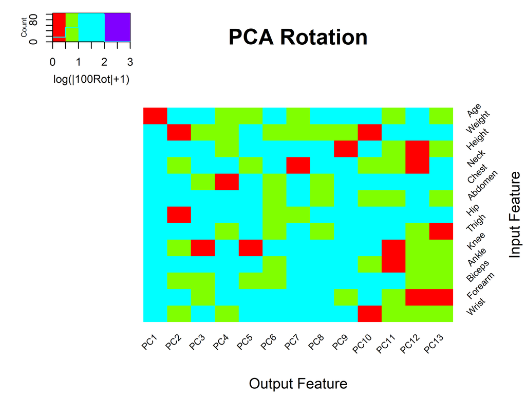

```r
rotstd <- log10(abs(100*pc$rotation)+1.0)
  gplots::heatmap.2(rotstd,
                    trace = "none",
                    dendrogram="none",
                    breaks=c(0,0.5,1,2,3),
#                    scale="row",
                    mar = c(5,5),
                    col=rainbow(4),
                    main = "PCA Rotation",
                    cexRow = cexheat,
                    cexCol = cexheat,
                    Rowv=FALSE,
                    Colv=FALSE,
                   srtCol=45,
                   srtRow=45,
                    key.title=NA,
                    key.xlab="log(|100Rot|+1)",
                    xlab="Output Feature", ylab="Input Feature")
```

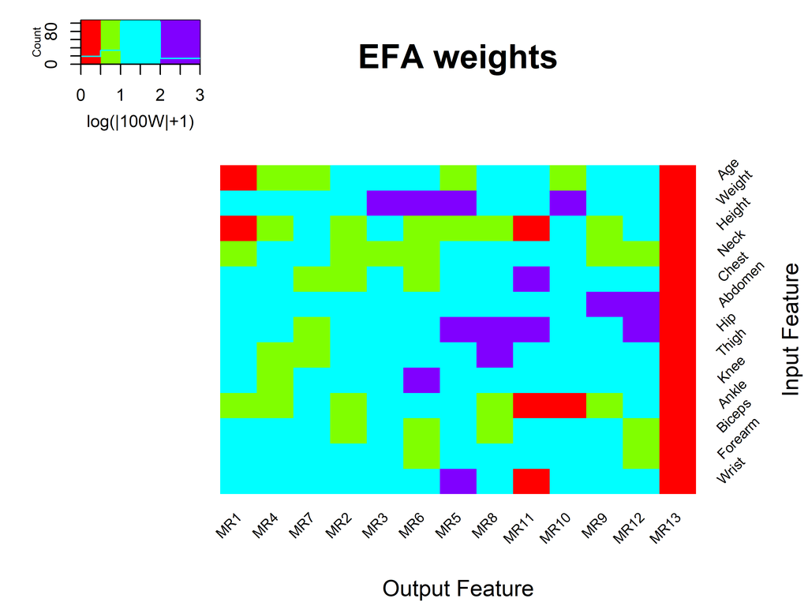

```r
efa <- try(fa(dataframe[,toPCA],ncol(pc$rotation),rotate="varimax",warnings=FALSE))  # EFA analysis

if (!inherits(efa,"try-error"))
{
  if (ncol(dataframe)<20)
  {
   pander::pander(as.data.frame(efa$weights),caption="EFA")
  rotstd <- log10(abs(100*efa$weights)+1.0)
    gplots::heatmap.2(rotstd,
                      trace = "none",
                      dendrogram="none",
                      breaks=c(0,0.5,1,2,3),
  #                    scale="row",
                      mar = c(5,5),
                      col=rainbow(4),
                      main = "EFA weights",
                      cexRow = cexheat,
                      cexCol = cexheat,
                      Rowv=FALSE,
                      Colv=FALSE,
                     srtCol=45,
                     srtRow=45,
                      key.title=NA,
                      key.xlab="log(|100W|+1)",
                      xlab="Output Feature", ylab="Input Feature")
  }
}
```

[output not shown]

```r
plm <- plsr(formula=formula(paste(outcome,"~.")),data=dataframe,scale =TRUE)
if (ncol(dataframe)<20)
{
  lds <- plm$loadings
  lds2 <- matrix(as.numeric(lds),nrow=nrow(lds),ncol=ncol(lds))
  colnames(lds2) <- colnames(lds)
  rownames(lds2) <- rownames(lds)
  pander::pander(lds2,caption="PLS")
}
```

PLS

|  | Comp 1 | Comp 2 | Comp 3 | Comp 4 | Comp 5 | Comp 6 | Comp 7 | Comp 8 | Comp 9 | Comp 10 | Comp 11 | Comp 12 | Comp 13 |
| --- | --- | --- | --- | --- | --- | --- | --- | --- | --- | --- | --- | --- | --- |
| **Age** | 0.0384 | 0.57608 | -0.6875 | 0.7478 | -0.41789 | 0.00471 | -0.0761 | 0.10245 | -0.37453 | 0.01428 | 0.1080 | 0.2376 | -0.28062 |
| **Weight** | 0.3562 | -0.08577 | 0.1436 | -0.0683 | -0.20422 | -0.00403 | -0.0936 | -0.04584 | 0.02295 | -0.20848 | -0.2603 | -0.2984 | -0.06567 |
| **Height** | 0.0760 | -0.62143 | 0.2716 | 0.5959 | -0.92161 | 0.40989 | 0.0618 | -0.14581 | -0.00432 | 0.00165 | 0.0509 | 0.1227 | -0.07420 |
| **Neck** | 0.3161 | -0.08098 | -0.3655 | -0.0146 | -0.13866 | 0.14203 | 0.2369 | -0.12786 | 0.53456 | -0.87736 | 0.6928 | -0.1367 | -0.13499 |
| **Chest** | 0.3381 | 0.15815 | 0.1224 | 0.1010 | -0.17174 | -0.21335 | -0.0436 | -0.09300 | 0.44268 | -0.14630 | -0.2084 | 0.1896 | 0.47454 |
| **Abdomen** | 0.3379 | 0.25099 | 0.2404 | 0.1292 | 0.01884 | 0.33627 | -0.0425 | 0.00247 | 0.16578 | 0.04487 | -0.0127 | -0.2395 | 0.06280 |
| **Hip** | 0.3408 | 0.00303 | 0.2523 | -0.2796 | -0.15177 | 0.00364 | -0.1979 | -0.05027 | -0.12750 | 0.58828 | 0.2592 | -0.3429 | -0.12910 |
| **Thigh** | 0.3195 | -0.09734 | 0.2962 | -0.4286 | 0.17340 | 0.18765 | -0.0593 | -0.14376 | -0.52426 | -0.26922 | 0.2559 | 0.3428 | 0.00953 |
| **Knee** | 0.3161 | -0.13333 | 0.0318 | -0.1155 | -0.23851 | 0.06294 | 0.1724 | 0.70035 | -0.51326 | 0.22642 | -0.1638 | 0.0435 | 0.09049 |
| **Ankle** | 0.2245 | -0.35117 | -0.0426 | 0.1850 | 0.47509 | -0.27208 | -0.8964 | 0.62422 | 0.03005 | -0.20293 | 0.1301 | 0.1241 | -0.15447 |
| **Biceps** | 0.3067 | -0.13624 | -0.0459 | -0.0987 | 0.23737 | -0.12850 | 0.2999 | -0.27227 | 0.23005 | 0.33561 | -0.5523 | 0.8472 | -0.66102 |
| **Forearm** | 0.2489 | -0.25932 | -0.0386 | 0.2871 | 0.59972 | -0.71664 | 0.6784 | -0.30636 | -0.21534 | 0.04722 | 0.2028 | -0.3232 | 0.16145 |
| **Wrist** | 0.2828 | -0.20726 | -0.7423 | 0.2230 | -0.00939 | 0.28827 | -0.1485 | -0.15622 | -0.06604 | 0.46004 | -0.3119 | -0.2325 | 0.39020 |

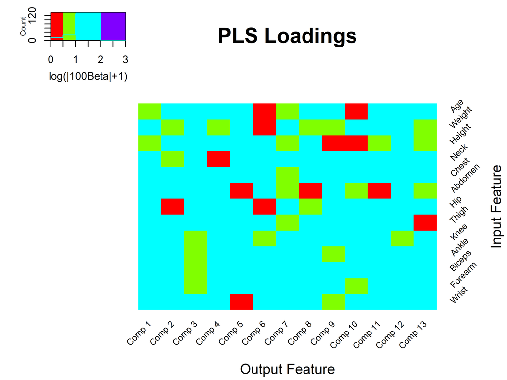

```r
loadadings <- log10(abs(100*plm$loadings) + 1.0)
  gplots::heatmap.2(loadadings,
                    breaks=c(0,0.5,1,2,3),
                    trace = "none",
                    dendrogram="none",
#                    scale="row",
                    mar = c(5,5),
                    col=rainbow(4),
                    main = "PLS Loadings",
                    cexRow = cexheat,
                    cexCol = cexheat,
                    Rowv=FALSE,
                    Colv=FALSE,
                   srtCol=45,
                   srtRow=45,
                    key.title=NA,
                    key.xlab="log(|100Beta|+1)",
                    xlab="Output Feature", ylab="Input Feature")
```

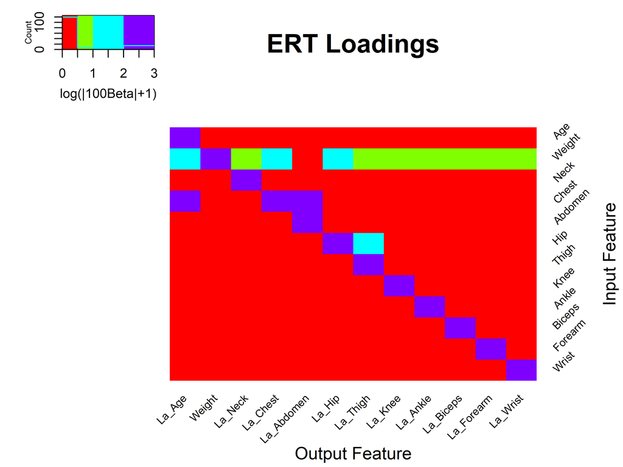

```r
ERTmod <- ILAA(dataframe,Outcome = outcome,thr=thro)

ERT <- log10(abs(100*attr(ERTmod,"UPLTM")) + 1);
  gplots::heatmap.2(ERT,
                    trace = "none",
                    breaks=c(0,0.5,1,2,3),
                    mar = c(5,5),
                    col=rainbow(4),
                    main = "ERT Loadings",
                    cexRow = cexheat,
                    cexCol = cexheat,
                    dendrogram="none",
                    Rowv=FALSE,
                    Colv=FALSE,
                   srtCol=45,
                   srtRow=45,
                    key.title=NA,
                    key.xlab="log(|100Beta|+1)",
                    xlab="Output Feature", ylab="Input Feature")
```

```r
if (ncol(dataframe)<20)
{
pander::pander(attr(ERTmod,"UPLTM"),caption="ERT")
}
```

ERT

|  | La_Age | Weight | La_Neck | La_Chest | La_Abdomen | La_Hip | La_Thigh | La_Knee | La_Ankle | La_Biceps | La_Forearm | La_Wrist |
| --- | --- | --- | --- | --- | --- | --- | --- | --- | --- | --- | --- | --- |
| **Age** | 1.000 | 0 | 0.0000 | 0.000 | 0.00 | 0.000 | 0.0000 | 0.00 | 0.0000 | 0.0000 | 0.0000 | 0.0000 |
| **Weight** | 0.359 | 1 | -0.0687 | -0.257 | 0.00 | -0.229 | -0.0394 | -0.07 | -0.0354 | -0.0823 | -0.0433 | -0.0232 |
| **Neck** | 0.000 | 0 | 1.0000 | 0.000 | 0.00 | 0.000 | 0.0000 | 0.00 | 0.0000 | 0.0000 | 0.0000 | 0.0000 |
| **Chest** | -1.401 | 0 | 0.0000 | 1.000 | -1.17 | 0.000 | 0.0000 | 0.00 | 0.0000 | 0.0000 | 0.0000 | 0.0000 |
| **Abdomen** | 0.000 | 0 | 0.0000 | 0.000 | 1.00 | 0.000 | 0.0000 | 0.00 | 0.0000 | 0.0000 | 0.0000 | 0.0000 |
| **Hip** | 0.000 | 0 | 0.0000 | 0.000 | 0.00 | 1.000 | -0.5050 | 0.00 | 0.0000 | 0.0000 | 0.0000 | 0.0000 |
| **Thigh** | 0.000 | 0 | 0.0000 | 0.000 | 0.00 | 0.000 | 1.0000 | 0.00 | 0.0000 | 0.0000 | 0.0000 | 0.0000 |
| **Knee** | 0.000 | 0 | 0.0000 | 0.000 | 0.00 | 0.000 | 0.0000 | 1.00 | 0.0000 | 0.0000 | 0.0000 | 0.0000 |
| **Ankle** | 0.000 | 0 | 0.0000 | 0.000 | 0.00 | 0.000 | 0.0000 | 0.00 | 1.0000 | 0.0000 | 0.0000 | 0.0000 |
| **Biceps** | 0.000 | 0 | 0.0000 | 0.000 | 0.00 | 0.000 | 0.0000 | 0.00 | 0.0000 | 1.0000 | 0.0000 | 0.0000 |
| **Forearm** | 0.000 | 0 | 0.0000 | 0.000 | 0.00 | 0.000 | 0.0000 | 0.00 | 0.0000 | 0.0000 | 1.0000 | 0.0000 |
| **Wrist** | 0.000 | 0 | 0.0000 | 0.000 | 0.00 | 0.000 | 0.0000 | 0.00 | 0.0000 | 0.0000 | 0.0000 | 1.0000 |

## 1.5 SOTA Comparison to PLS, PC, LASSO, and ENET

### 1.5.1 PLSR

```r
PLScv <- randomCV(dataframe,outcome,plfit,
                        trainFraction = tfrac,
                        repetitions = loops)
```

……….10 Tested: 221 Avg. Selected: 0 Min Tests: 1 Max Tests: 5 Mean Tests: 2.307692 . MAD: 3.675806 ……….20 Tested: 250 Avg. Selected: 0 Min Tests: 1 Max Tests: 10 Mean Tests: 4.08 . MAD: 3.67366 ……….30 Tested: 252 Avg. Selected: 0 Min Tests: 1 Max Tests: 13 Mean Tests: 6.071429 . MAD: 3.676872 ……….40 Tested: 252 Avg. Selected: 0 Min Tests: 2 Max Tests: 18 Mean Tests: 8.095238 . MAD: 3.687972 ……….50 Tested: 252 Avg. Selected: 0 Min Tests: 3 Max Tests: 18 Mean Tests: 10.11905 . MAD: 3.675305 ……….60 Tested: 252 Avg. Selected: 0 Min Tests: 4 Max Tests: 22 Mean Tests: 12.14286 . MAD: 3.669162 ……….70 Tested: 252 Avg. Selected: 0 Min Tests: 5 Max Tests: 26 Mean Tests: 14.16667 . MAD: 3.66606 ……….80 Tested: 252 Avg. Selected: 0 Min Tests: 8 Max Tests: 28 Mean Tests: 16.19048 . MAD: 3.662387 ……….90 Tested: 252 Avg. Selected: 0 Min Tests: 9 Max Tests: 31 Mean Tests: 18.21429 . MAD: 3.661662 ……….100 Tested: 252 Avg. Selected: 0 Min Tests: 10 Max Tests: 34 Mean Tests: 20.2381 . MAD: 3.670488

```r
PLSbs <- predictionStats_regression(PLScv$medianTest,"PLS: CV")
```

PLS: CV

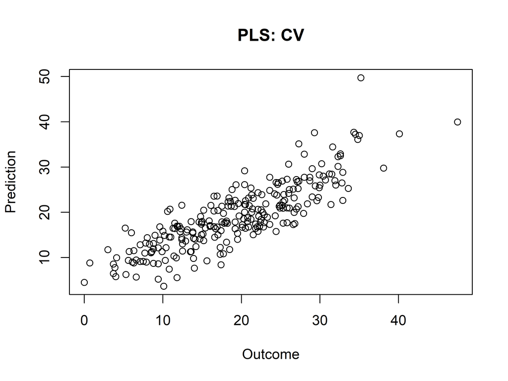

### 1.5.2 PC

```r
PCcv <- randomCV(fittingFunction = pcrfit,
                     trainSampleSets = PLScv$trainSamplesSets
                    )
```

……….10 Tested: 221 Avg. Selected: 0 Min Tests: 1 Max Tests: 5 Mean Tests: 2.307692 . MAD: 3.675806 ……….20 Tested: 250 Avg. Selected: 0 Min Tests: 1 Max Tests: 10 Mean Tests: 4.08 . MAD: 3.67366 ……….30 Tested: 252 Avg. Selected: 0 Min Tests: 1 Max Tests: 13 Mean Tests: 6.071429 . MAD: 3.676872 ……….40 Tested: 252 Avg. Selected: 0 Min Tests: 2 Max Tests: 18 Mean Tests: 8.095238 . MAD: 3.687972 ……….50 Tested: 252 Avg. Selected: 0 Min Tests: 3 Max Tests: 18 Mean Tests: 10.11905 . MAD: 3.675305 ……….60 Tested: 252 Avg. Selected: 0 Min Tests: 4 Max Tests: 22 Mean Tests: 12.14286 . MAD: 3.669162 ……….70 Tested: 252 Avg. Selected: 0 Min Tests: 5 Max Tests: 26 Mean Tests: 14.16667 . MAD: 3.66606 ……….80 Tested: 252 Avg. Selected: 0 Min Tests: 8 Max Tests: 28 Mean Tests: 16.19048 . MAD: 3.662387 ……….90 Tested: 252 Avg. Selected: 0 Min Tests: 9 Max Tests: 31 Mean Tests: 18.21429 . MAD: 3.661662 ……….100 Tested: 252 Avg. Selected: 0 Min Tests: 10 Max Tests: 34 Mean Tests: 20.2381 . MAD: 3.670488

```r
PCbs <- predictionStats_regression(PCcv$medianTest,"PCR: CV")
```

PCR: CV

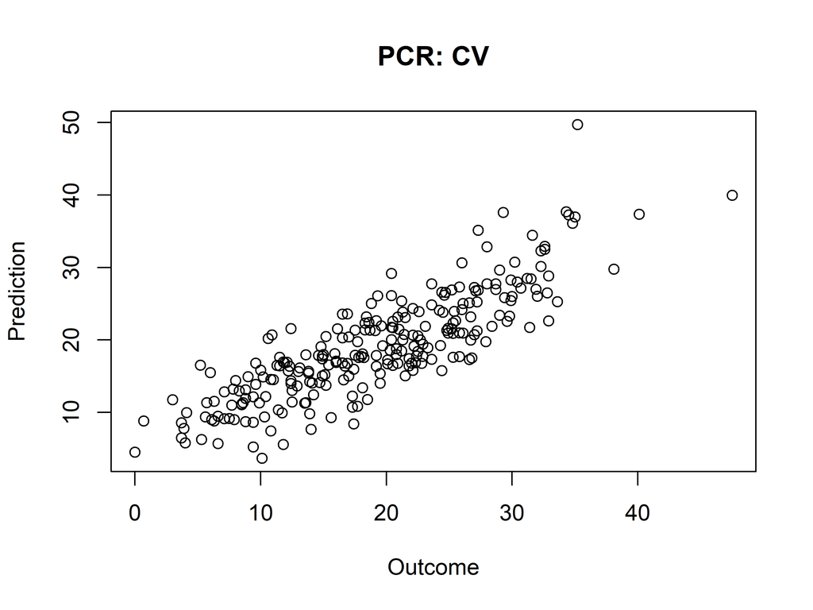

### 1.5.3 CPP

```r
#CPPlcv <- randomCV(fittingFunction = cpplsfit,
#                     trainSampleSets = PLScv$trainSamplesSets
#                    )

#CPPlbs <- predictionStats_regression(CPPlcv$medianTest,"cppls: CV")
```

### 1.5.4 LASSO

```r
LASSOcv <- randomCV(fittingFunction = LASSO_MIN,
                     trainSampleSets = PLScv$trainSamplesSets)
```

……….10 Tested: 221 Avg. Selected: 9.4 Min Tests: 1 Max Tests: 5 Mean Tests: 2.307692 . MAD: 3.649613 ……….20 Tested: 250 Avg. Selected: 9.75 Min Tests: 1 Max Tests: 10 Mean Tests: 4.08 . MAD: 3.677506 ……….30 Tested: 252 Avg. Selected: 10.3 Min Tests: 1 Max Tests: 13 Mean Tests: 6.071429 . MAD: 3.658175 ……….40 Tested: 252 Avg. Selected: 10.25 Min Tests: 2 Max Tests: 18 Mean Tests: 8.095238 . MAD: 3.676777 ……….50 Tested: 252 Avg. Selected: 10.12 Min Tests: 3 Max Tests: 18 Mean Tests: 10.11905 . MAD: 3.670272 ……….60 Tested: 252 Avg. Selected: 10.35 Min Tests: 4 Max Tests: 22 Mean Tests: 12.14286 . MAD: 3.667169 ……….70 Tested: 252 Avg. Selected: 10.47143 Min Tests: 5 Max Tests: 26 Mean Tests: 14.16667 . MAD: 3.660879 ……….80 Tested: 252 Avg. Selected: 10.6 Min Tests: 8 Max Tests: 28 Mean Tests: 16.19048 . MAD: 3.650539 ……….90 Tested: 252 Avg. Selected: 10.65556 Min Tests: 9 Max Tests: 31 Mean Tests: 18.21429 . MAD: 3.634991 ……….100 Tested: 252 Avg. Selected: 10.67 Min Tests: 10 Max Tests: 34 Mean Tests: 20.2381 . MAD: 3.63918

```r
LASSObs <- predictionStats_regression(LASSOcv$medianTest,"LASSO: CV")
```

LASSO: CV

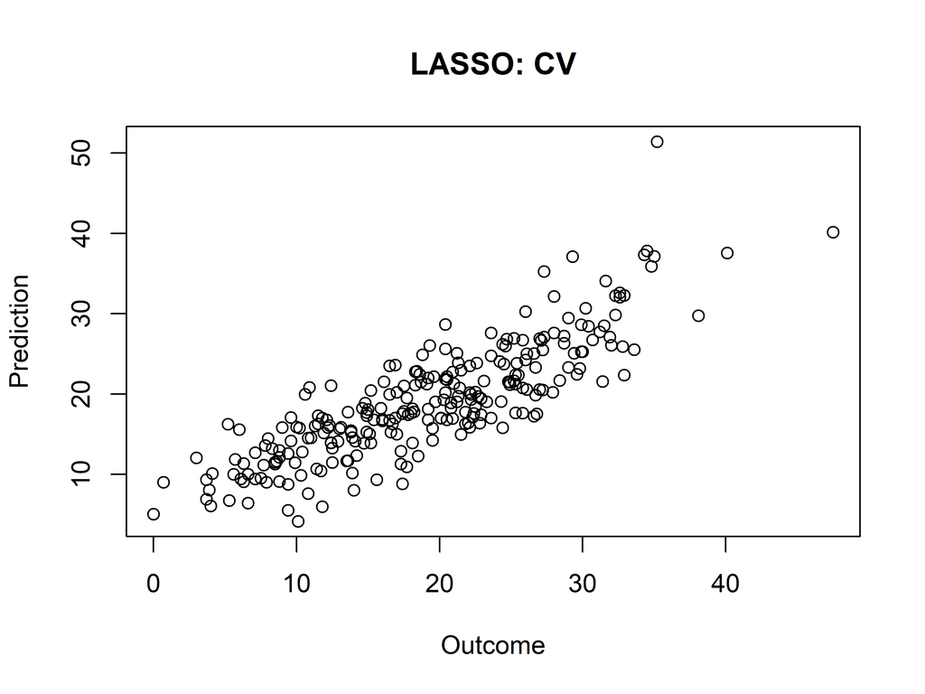

### 1.5.5 PCA LASSO

```r
PCALASSOcv <- randomCV(fittingFunction = filteredFit,
                     trainSampleSets = PLScv$trainSamplesSets,
                     fitmethod = LASSO_MIN,
                      filtermethod = NULL,
                    PCA = TRUE)
```

..........10 Tested: 221 Avg. Selected: 10.6 Min Tests: 1 Max Tests: 5 Mean Tests: 2.307692 . MAD: 3.666297 ..........20 Tested: 250 Avg. Selected: 10.7 Min Tests: 1 Max Tests: 10 Mean Tests: 4.08 . MAD: 3.68461 ..........30 Tested: 252 Avg. Selected: 10.76667 Min Tests: 1 Max Tests: 13 Mean Tests: 6.071429 . MAD: 3.655305 ..........40 Tested: 252 Avg. Selected: 10.425 Min Tests: 2 Max Tests: 18 Mean Tests: 8.095238 . MAD: 3.676823 ..........50 Tested: 252 Avg. Selected: 10.46 Min Tests: 3 Max Tests: 18 Mean Tests: 10.11905 . MAD: 3.654154 ..........60 Tested: 252 Avg. Selected: 10.75 Min Tests: 4 Max Tests: 22 Mean Tests: 12.14286 . MAD: 3.66229 ..........70 Tested: 252 Avg. Selected: 10.91429 Min Tests: 5 Max Tests: 26 Mean Tests: 14.16667 . MAD: 3.656086 ..........80 Tested: 252 Avg. Selected: 10.875 Min Tests: 8 Max Tests: 28 Mean Tests: 16.19048 . MAD: 3.655311 ..........90 Tested: 252 Avg. Selected: 10.82222 Min Tests: 9 Max Tests: 31 Mean Tests: 18.21429 . MAD: 3.658466 ..........100 Tested: 252 Avg. Selected: 10.84 Min Tests: 10 Max Tests: 34 Mean Tests: 20.2381 . MAD: 3.660946

```r
PCALASSObs <- predictionStats_regression(PCALASSOcv$medianTest,"PCA-LASSO: CV")
```

PCA-LASSO: CV

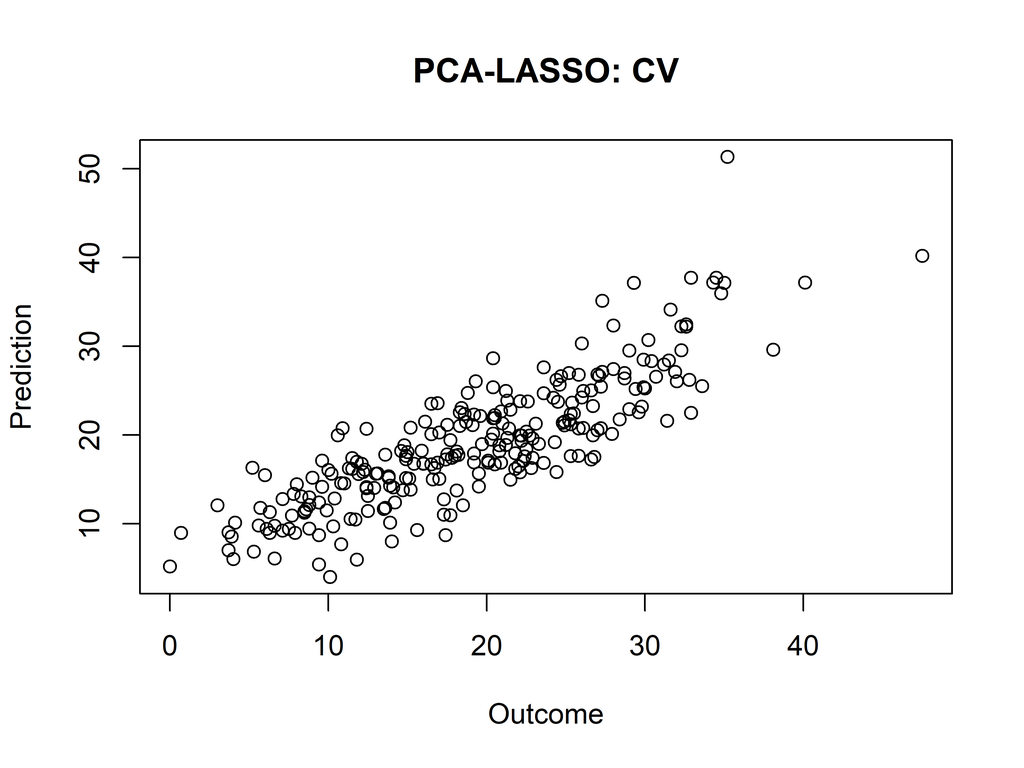

### 1.5.6 ILAA LASSO

```r
ILAALASSOcv <- randomCV(fittingFunction = filteredFit,
                     trainSampleSets = PLScv$trainSamplesSets,
                     fitmethod = LASSO_MIN,
                      filtermethod = NULL,
                    DECOR = TRUE,
                    DECOR.control=list(thr=thro,Outcome=outcome))
```

..........10 Tested: 221 Avg. Selected: 10.9 Min Tests: 1 Max Tests: 5 Mean Tests: 2.307692 . MAD: 3.659447 ..........20 Tested: 250 Avg. Selected: 10.85 Min Tests: 1 Max Tests: 10 Mean Tests: 4.08 . MAD: 3.662634 ..........30 Tested: 252 Avg. Selected: 10.76667 Min Tests: 1 Max Tests: 13 Mean Tests: 6.071429 . MAD: 3.663315 ..........40 Tested: 252 Avg. Selected: 10.525 Min Tests: 2 Max Tests: 18 Mean Tests: 8.095238 . MAD: 3.685756 ..........50 Tested: 252 Avg. Selected: 10.2 Min Tests: 3 Max Tests: 18 Mean Tests: 10.11905 . MAD: 3.666412 ..........60 Tested: 252 Avg. Selected: 10.3 Min Tests: 4 Max Tests: 22 Mean Tests: 12.14286 . MAD: 3.676587 ..........70 Tested: 252 Avg. Selected: 10.41429 Min Tests: 5 Max Tests: 26 Mean Tests: 14.16667 . MAD: 3.677102 ..........80 Tested: 252 Avg. Selected: 10.5875 Min Tests: 8 Max Tests: 28 Mean Tests: 16.19048 . MAD: 3.656831 ..........90 Tested: 252 Avg. Selected: 10.57778 Min Tests: 9 Max Tests: 31 Mean Tests: 18.21429 . MAD: 3.653675 ..........100 Tested: 252 Avg. Selected: 10.68 Min Tests: 10 Max Tests: 34 Mean Tests: 20.2381 . MAD: 3.651377

```r
ILAALASSObs <- predictionStats_regression(ILAALASSOcv$medianTest,"ILLA-LASSO: CV")
```

ILLA-LASSO: CV

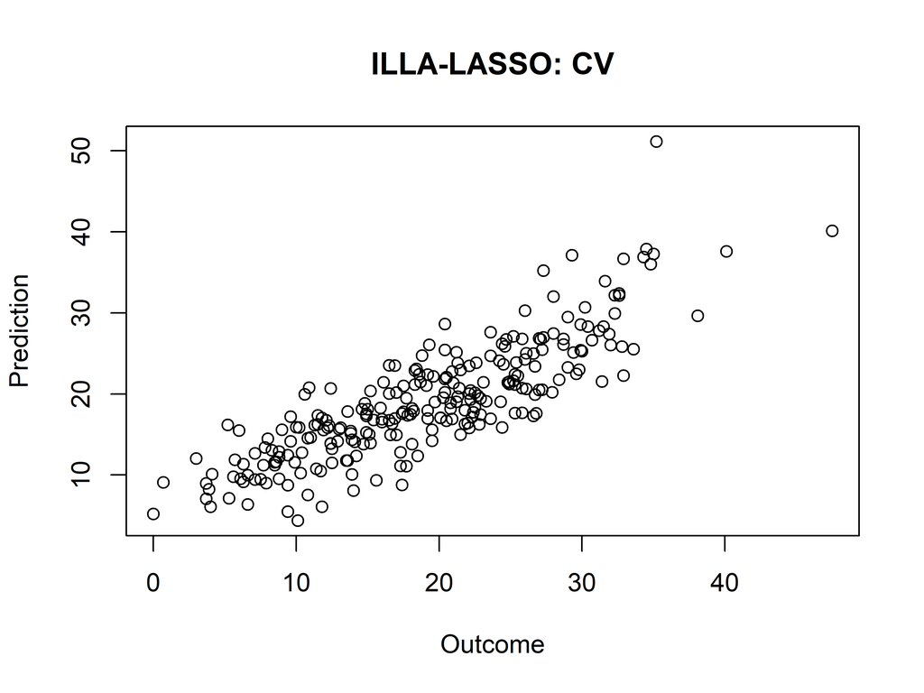

### 1.5.7 ENET

```r
ENETcv <- randomCV(fittingFunction = GLMNET_ELASTICNET_MIN,
                     trainSampleSets = PLScv$trainSamplesSets)
```

……….10 Tested: 221 Avg. Selected: 13 Min Tests: 1 Max Tests: 5 Mean Tests: 2.307692 . MAD: 3.812353 ……….20 Tested: 250 Avg. Selected: 13 Min Tests: 1 Max Tests: 10 Mean Tests: 4.08 . MAD: 3.809653 ……….30 Tested: 252 Avg. Selected: 13 Min Tests: 1 Max Tests: 13 Mean Tests: 6.071429 . MAD: 3.783202 ……….40 Tested: 252 Avg. Selected: 13 Min Tests: 2 Max Tests: 18 Mean Tests: 8.095238 . MAD: 3.799346 ……….50 Tested: 252 Avg. Selected: 13 Min Tests: 3 Max Tests: 18 Mean Tests: 10.11905 . MAD: 3.786638 ……….60 Tested: 252 Avg. Selected: 13 Min Tests: 4 Max Tests: 22 Mean Tests: 12.14286 . MAD: 3.793351 ……….70 Tested: 252 Avg. Selected: 13 Min Tests: 5 Max Tests: 26 Mean Tests: 14.16667 . MAD: 3.792638 ……….80 Tested: 252 Avg. Selected: 13 Min Tests: 8 Max Tests: 28 Mean Tests: 16.19048 . MAD: 3.787349 ……….90 Tested: 252 Avg. Selected: 13 Min Tests: 9 Max Tests: 31 Mean Tests: 18.21429 . MAD: 3.788891 ……….100 Tested: 252 Avg. Selected: 13 Min Tests: 10 Max Tests: 34 Mean Tests: 20.2381 . MAD: 3.79219

```r
ENETbs <- predictionStats_regression(ENETcv$medianTest,"ENET: CV")
```

ENET: CV

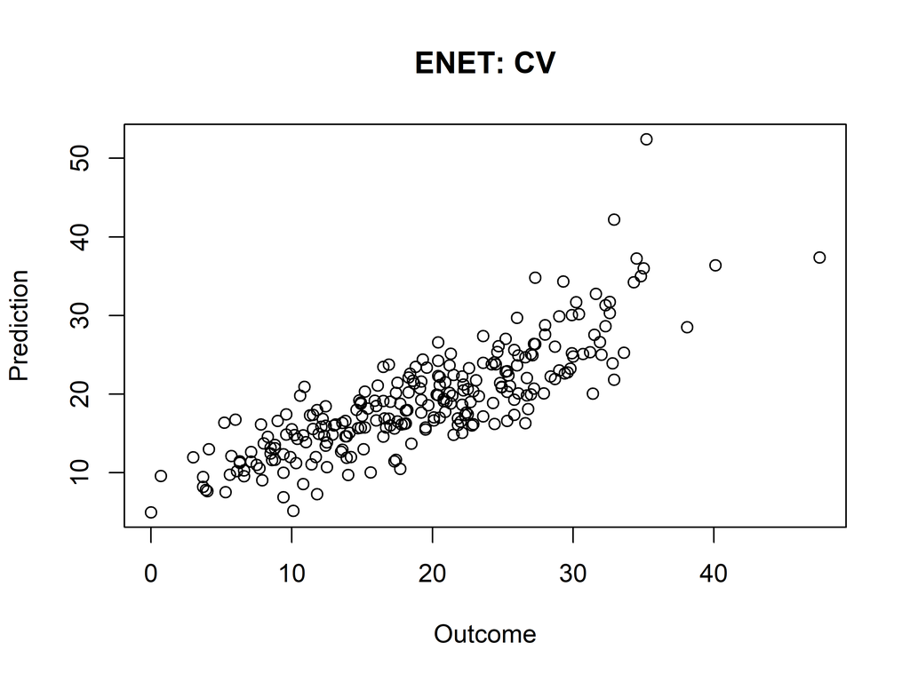

### 1.5.8 ILAAA ENET

```r
ILAAENETcv <- randomCV(fittingFunction = filteredFit,
                     trainSampleSets = PLScv$trainSamplesSets,
                     fitmethod = GLMNET_ELASTICNET_MIN,
                      filtermethod = NULL,
                    DECOR = TRUE,
                    DECOR.control=list(thr=thro,Outcome=outcome))
```

..........10 Tested: 221 Avg. Selected: 13 Min Tests: 1 Max Tests: 5 Mean Tests: 2.307692 . MAD: 3.812353 ..........20 Tested: 250 Avg. Selected: 13 Min Tests: 1 Max Tests: 10 Mean Tests: 4.08 . MAD: 3.809653 ..........30 Tested: 252 Avg. Selected: 13 Min Tests: 1 Max Tests: 13 Mean Tests: 6.071429 . MAD: 3.783202 ..........40 Tested: 252 Avg. Selected: 13 Min Tests: 2 Max Tests: 18 Mean Tests: 8.095238 . MAD: 3.799346 ..........50 Tested: 252 Avg. Selected: 13 Min Tests: 3 Max Tests: 18 Mean Tests: 10.11905 . MAD: 3.786638 ..........60 Tested: 252 Avg. Selected: 13 Min Tests: 4 Max Tests: 22 Mean Tests: 12.14286 . MAD: 3.793351 ..........70 Tested: 252 Avg. Selected: 13 Min Tests: 5 Max Tests: 26 Mean Tests: 14.16667 . MAD: 3.792638 ..........80 Tested: 252 Avg. Selected: 13 Min Tests: 8 Max Tests: 28 Mean Tests: 16.19048 . MAD: 3.787349 ..........90 Tested: 252 Avg. Selected: 13 Min Tests: 9 Max Tests: 31 Mean Tests: 18.21429 . MAD: 3.788891 ..........100 Tested: 252 Avg. Selected: 13 Min Tests: 10 Max Tests: 34 Mean Tests: 20.2381 . MAD: 3.79219

```r
ILAAENETbs <- predictionStats_regression(ILAAENETcv$medianTest,"ILLA-ENET: CV")
```

ILLA-ENET: CV

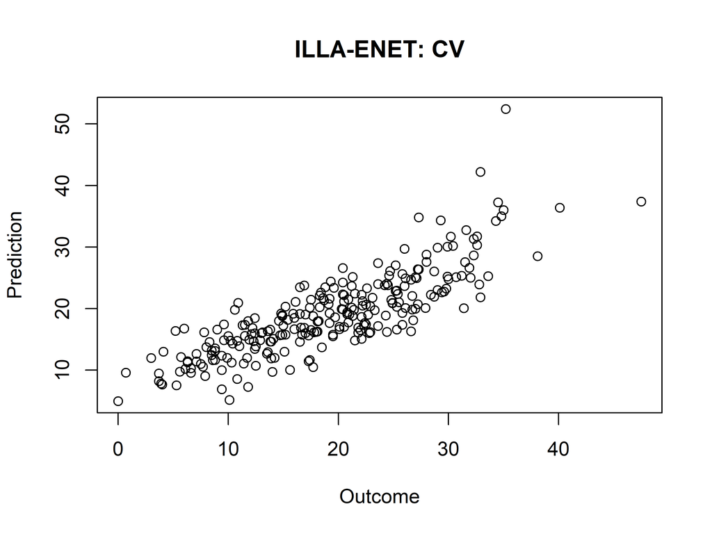

## 1.6 The Reports

```r
par(op)
RMSTABLE <- rbind(
                  PLSbs$RMSEci,
                  PCbs$RMSEci,
#                  CPPlbs$RMSEci,
                  LASSObs$RMSEci,
                  PCALASSObs$RMSEci,
                  ILAALASSObs$RMSEci,
                  ENETbs$RMSEci,
                  ILAAENETbs$RMSEci
                  )
colnames(RMSTABLE) <- c("Median","Lower","Upper")
#rownames(RMSTABLE) <- c("PLSR","PCR","CPP",
#                        "LASSO","PCA-LASSO","ILAA-LASSO","ENET","ILAA-ENET")

rownames(RMSTABLE) <- c("PLSR","PCR",
                        "LASSO","PCA-LASSO","ILAA-LASSO",
                        "ENET","ILAA-ENET")

pander::pander(RMSTABLE)
```

|  | Median | Lower | Upper |
| --- | --- | --- | --- |
| **PLSR** | 4.49 | 4.13 | 4.91 |
| **PCR** | 4.49 | 4.13 | 4.91 |
| **LASSO** | 4.49 | 4.13 | 4.92 |
| **PCA-LASSO** | 4.50 | 4.13 | 4.93 |
| **ILAA-LASSO** | 4.49 | 4.13 | 4.91 |
| **ENET** | 4.68 | 4.31 | 5.13 |
| **ILAA-ENET** | 4.68 | 4.31 | 5.13 |

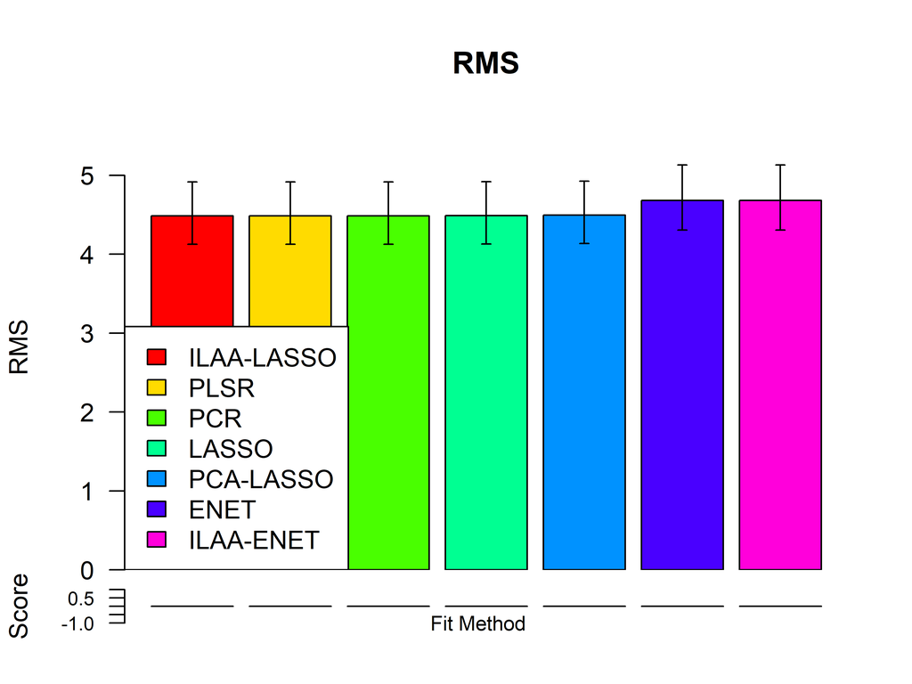

```r
themethod <- rownames(RMSTABLE)
thesets <- c("Fit Method")
pRMS <- barPlotCiError(RMSTABLE,
               "RMS",
               thesets=thesets,
               themethod=themethod,
               main="RMS",
               angle=0,
               offsets=c(0.1,1.0),
               scoreDirection="<",args.legend=list(x="bottomleft"),
               col=rainbow(length(themethod)))

par(op)
```

```r
MADTABLE <- rbind(
                  PLSbs$MAEci,
                  PCbs$MAEci,
#                  CPPlbs$MAEci,
                  LASSObs$MAEci,
                  PCALASSObs$MAEci,
                  ILAALASSObs$MAEci,
                  ENETbs$MAEci,
                  ILAAENETbs$MAEci
                  )


colnames(MADTABLE) <- colnames(RMSTABLE)
rownames(MADTABLE) <- rownames(RMSTABLE)

pander::pander(MADTABLE)
```

|  | Median | Lower | Upper |
| --- | --- | --- | --- |
| **PLSR** | 3.67 | 3.35 | 4.00 |
| **PCR** | 3.67 | 3.36 | 4.00 |
| **LASSO** | 3.64 | 3.32 | 3.98 |
| **PCA-LASSO** | 3.66 | 3.35 | 3.99 |
| **ILAA-LASSO** | 3.65 | 3.33 | 3.98 |
| **ENET** | 3.79 | 3.46 | 4.13 |
| **ILAA-ENET** | 3.80 | 3.46 | 4.15 |

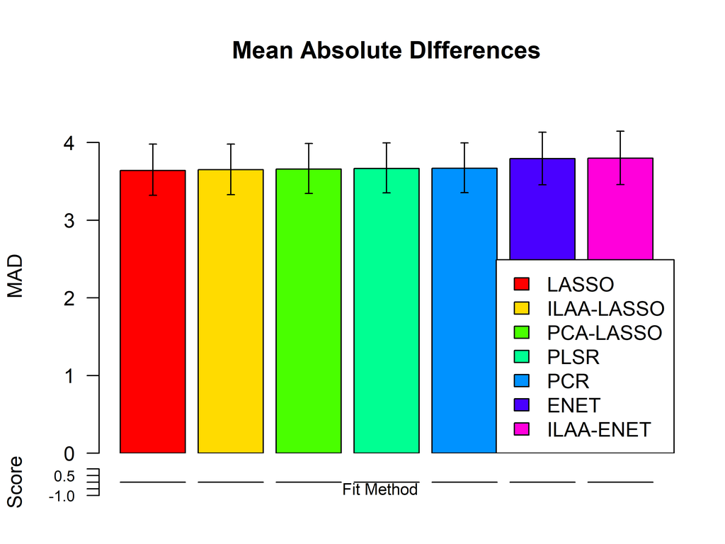

```r
pber <- barPlotCiError(MADTABLE,
               "MAD",
               thesets=thesets,
               themethod=themethod,
               main="Mean Absolute DIfferences",
               angle=0,
               offsets=c(0.1,0.5),
               scoreDirection="<",args.legend=list(x="bottomright"),
               col=rainbow(length(themethod))
               )
```

```r
PearsonTABLE <- rbind(
                  PLSbs$corci,
                  PCbs$corci,
#                  CPPlbs$corci,
                  LASSObs$corci,
                  PCALASSObs$corci,
                  ILAALASSObs$corci,
                  ENETbs$corci,
                  ILAAENETbs$corci
                  )


colnames(PearsonTABLE) <- colnames(RMSTABLE)
rownames(PearsonTABLE) <- rownames(RMSTABLE)

pander::pander(PearsonTABLE)
```

|  | Median | Lower | Upper |
| --- | --- | --- | --- |
| **PLSR** | 0.844 | 0.804 | 0.876 |
| **PCR** | 0.844 | 0.804 | 0.876 |
| **LASSO** | 0.844 | 0.804 | 0.876 |
| **PCA-LASSO** | 0.843 | 0.803 | 0.876 |
| **ILAA-LASSO** | 0.844 | 0.804 | 0.876 |
| **ENET** | 0.828 | 0.785 | 0.864 |
| **ILAA-ENET** | 0.828 | 0.785 | 0.864 |

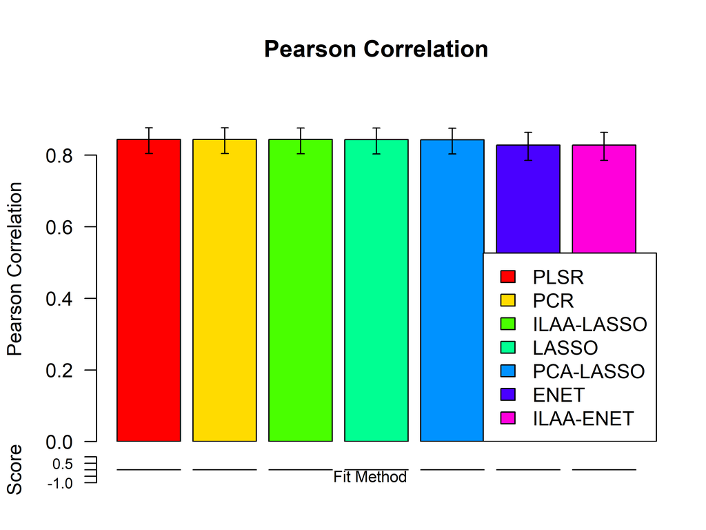

```r
pber <- barPlotCiError(PearsonTABLE,
               "Pearson Correlation",
               thesets=thesets,
               themethod=themethod,
               main="Pearson Correlation",
               angle=0,
               offsets=c(0.1,0.5),
               scoreDirection=">",args.legend=list(x="bottomright"),
               col=rainbow(length(themethod))
               )
```

### 1.6.1 Saving ALL

```r
save.image(paste("SOTACV_analyiss",studyName,".RData",sep="_"))
```